# Analyse de l’historique de ventes des livres

# 3 Analyse descriptive de l’historique excluant la catégorie scolaire

Les graphiques suivants montrent le comportement historique des ventes à Montréal et à Québec en excluant la catégorie “Scolaire”.

## 3.1 Record de ventes mensuelles

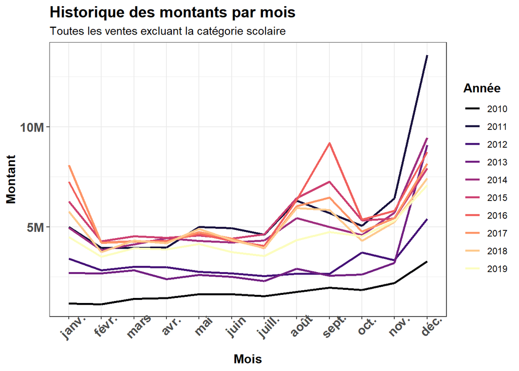

## 3.2 Record de ventes hebdomadaires

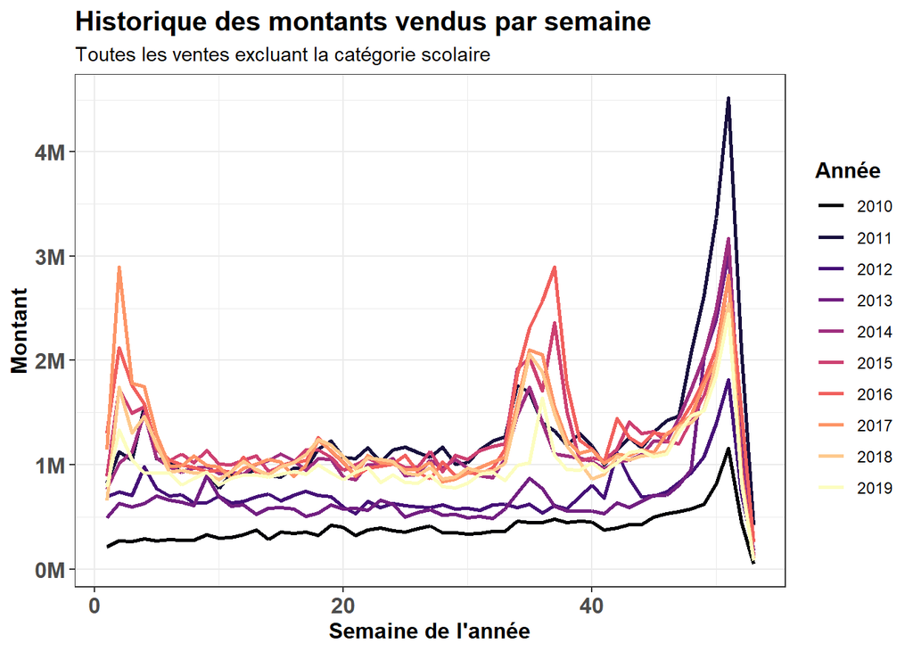

## 3.3 Record de ventes quotidiens

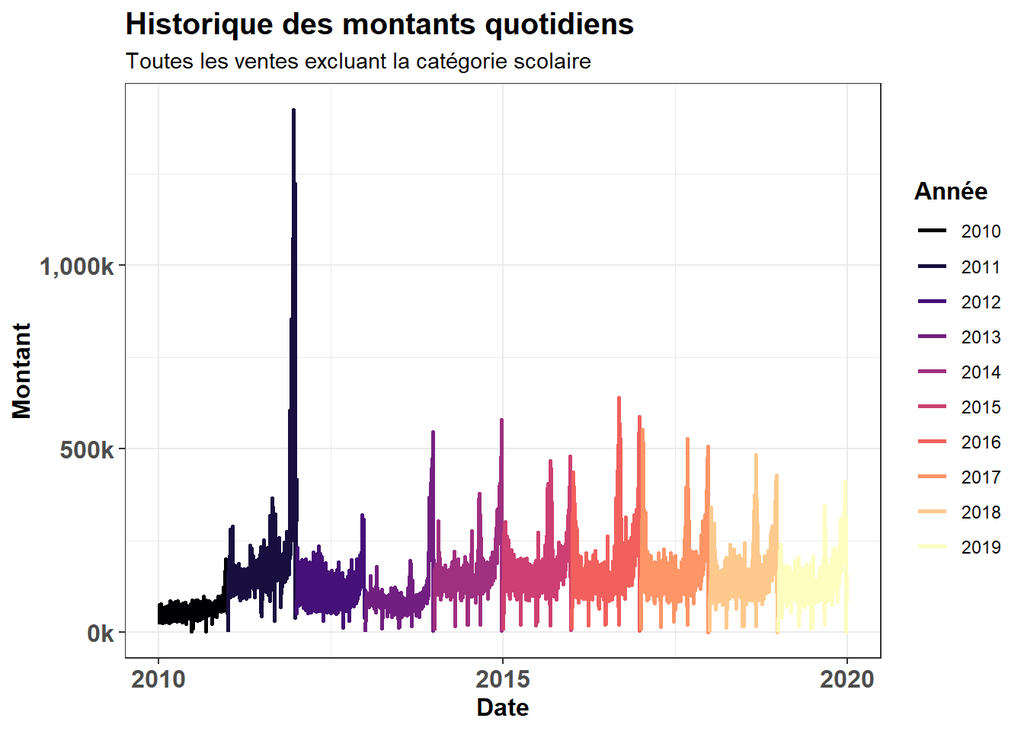

## 3.4 Historique des ventes quotidiennes durant le mois du salon du livre

### 3.4.1 Montréal

Le graphique ci-dessous montre le record de ventes quotidiennes à Montréal durant le mois de Novembre. La semaine où le Salon du livre a eu lieu se trouve marquée entre lignes.

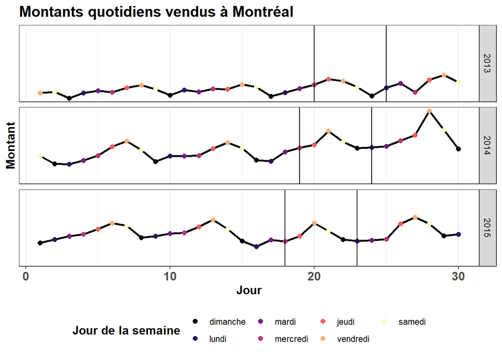

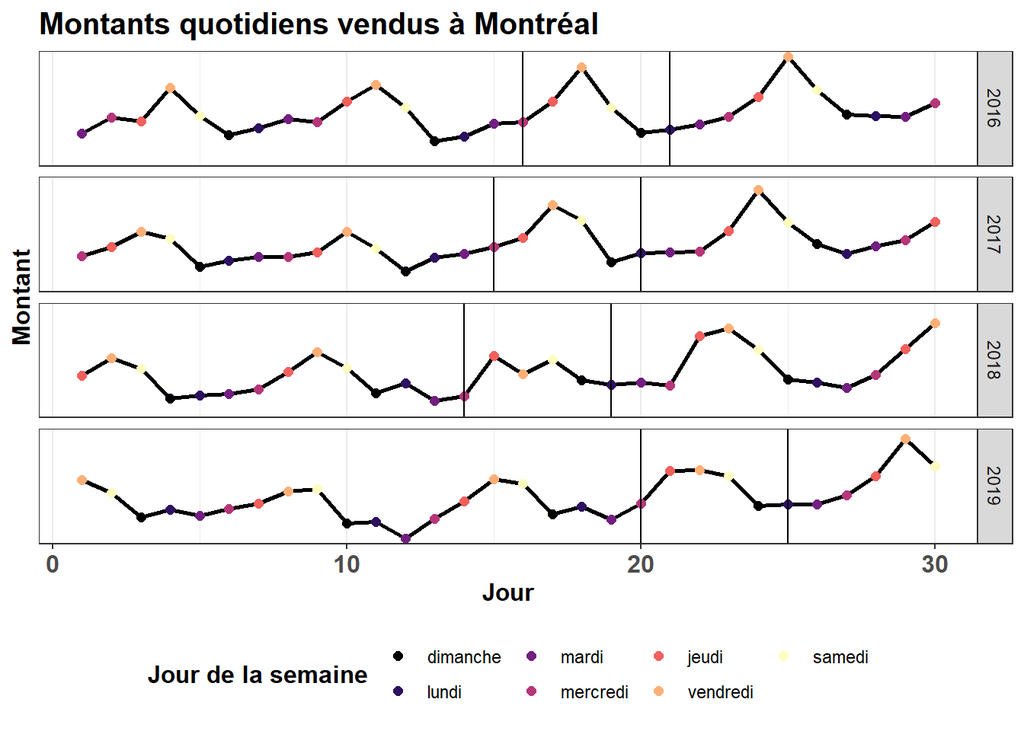

### 3.4.2 Québec

Le graphique ci-dessous montre le record de ventes quotidiennes à Québec durant le mois d’avril. La semaine où le Salon du livre a eu lieu se trouve marquée entre lignes.

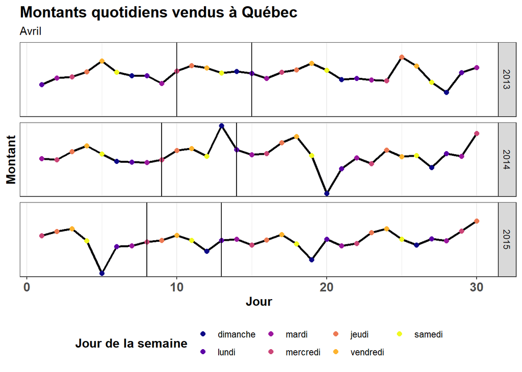

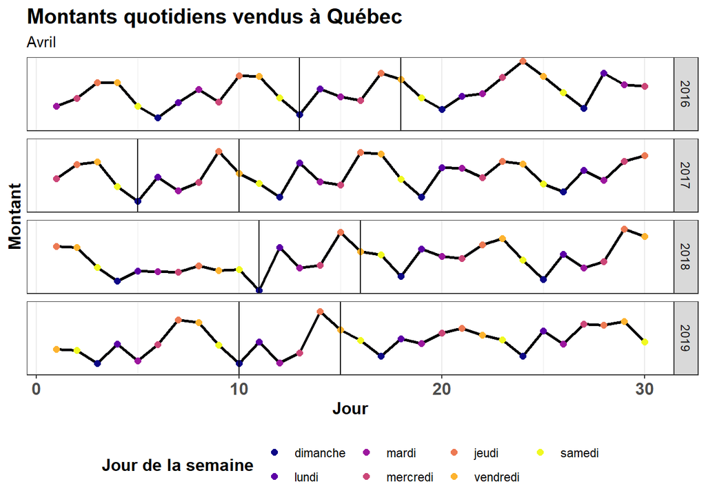

Le comportement des séries historiques ne semble pas changer lorsque nous excluons la catégorie scolaire. Concentrons-nous plutôt sur la catégorie la plus répandue au Salon du livre : soit littérature.

# 4 Analyse des ventes pour la catégorie littérature

## 4.1 Record de ventes mensuelles

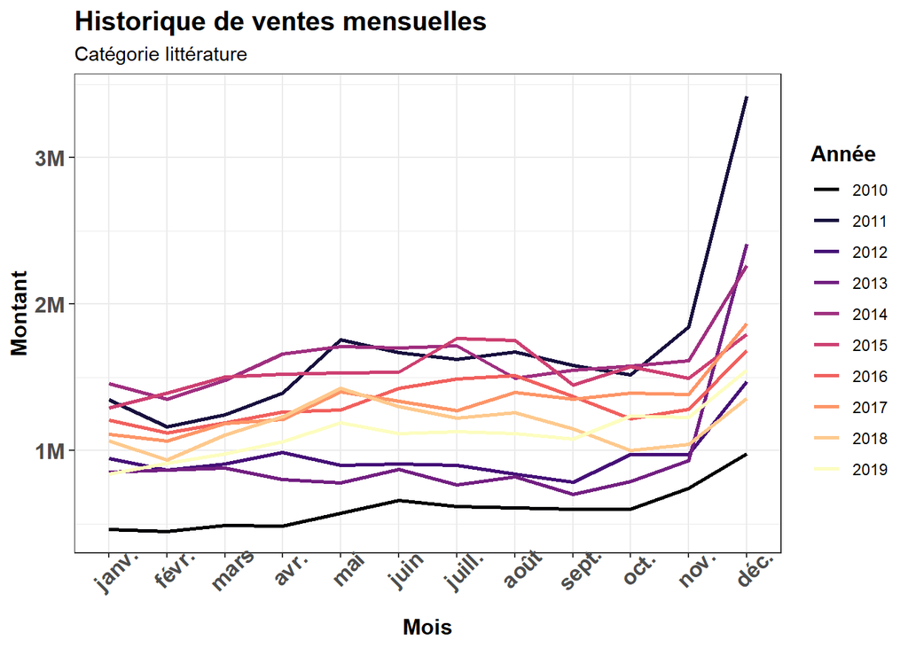

## 4.2 Record de ventes hebdomadaires

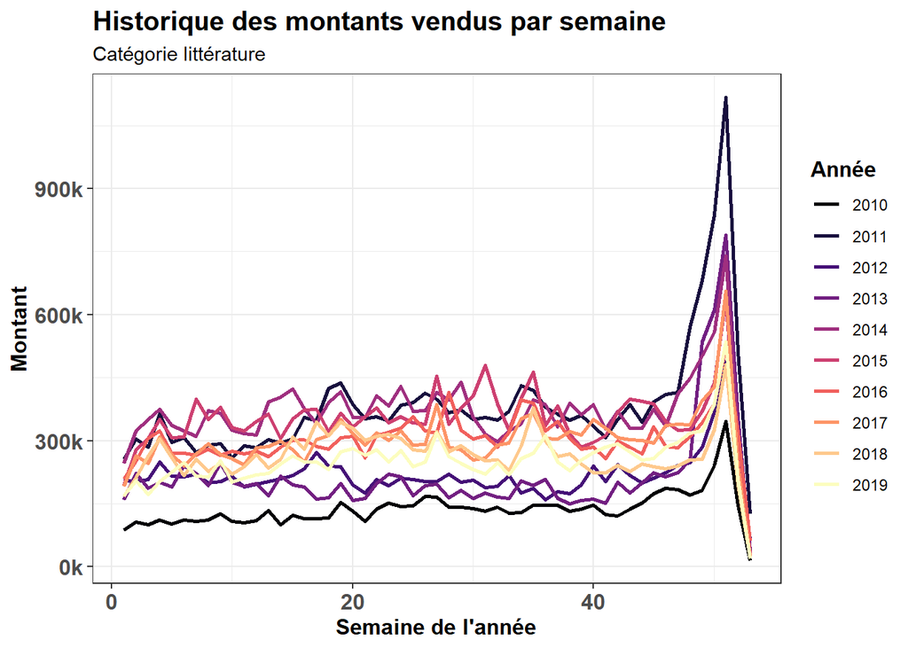

## 4.3 Historique des ventes quotidiennes durant le mois du salon du livre

### 4.3.1 Montréal

Le record de ventes montré ci-dessous correspond au mois de Novembre.

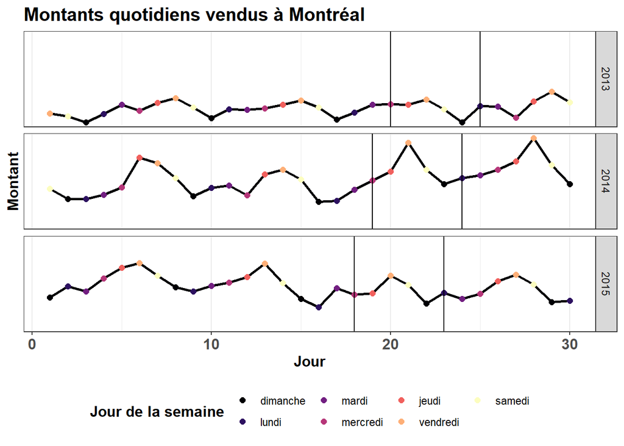

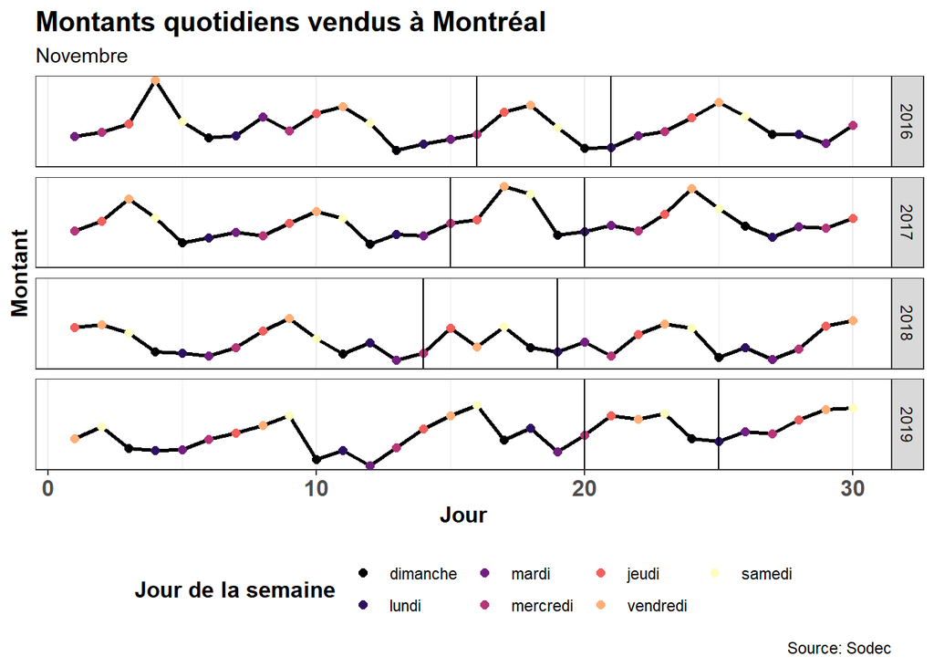